# Aula 9 - Econometria de Séries Temporais

Autor

João Ricardo F. de Lima

Data de Publicação

26 de maio de 2025

# Modelos ARCH-GARCH

Em geral, as análises feitas em econometria modelam a média condicional de uma variável aleatória $E(Y|X)$. Contudo, os modelos desta aula são diferentes: eles modelam a variância condicional (ou a volatilidade) de uma variável aleatória.

Existem várias razões pelas quais se pode querer modelar e prever a volatilidade:

- Avaliar o risco de manter um ativo;
- Construir intervalos de confiança dinâmicos;
- Obter estimadores mais eficientes ao lidar com heterocedasticidade.

Os modelos de heterocedasticidade condicional autorregressiva (ARCH) são projetados especificamente para modelar e prever variâncias condicionais. A variância condicional representa a variância da variável aleatória no tempo $t$, dada a informação disponível até o tempo $t - 1$. Isto significa que ao invés de assumir que a variância dos erros é constante (como em um modelo clássico de regressão), os modelos ARCH reconhecem que a incerteza sobre $y_t$ pode mudar ao longo do tempo, dependendo do comportamento passado.

Em termos matemáticos, se está modelando $\operatorname{Var}(\varepsilon_t \mid \mathcal{F}_{t-1}) = h_t$, onde $\mathcal{F}_{t-1}$ representa todo o conjunto de informações até o tempo $t-1$. Essa abordagem permite capturar períodos de alta e baixa volatilidade, algo frequentemente observado em séries financeiras e macroeconômicas.

Nos modelos ARCH, a variância condicional dos erros é modelada como uma função dos valores passados dos erros ao quadrado (choques anteriores). Isso permite capturar períodos de maior ou menor incerteza ao longo do tempo. Em versões mais gerais, como GARCH ou GARCH-X, a variância também pode depender da variância condicional passada ou de variáveis exógenas.

O modelo ARCH foi introduzido por Engle (1982) e generalizado como GARCH (*Generalized ARCH*) por Bollerslev (1986) e Taylor (1986). Esses modelos são amplamente utilizados em vários ramos da econometria, especialmente na análise de séries temporais financeiras.

A ideia central é que a variância condicional dos erros depende de erros passados:

$$y_t = \mu + \phi y_{t-1} + \varepsilon_t$$

$$h_t = \alpha_0 + \alpha_1 \varepsilon_{t-1}^2, \
\varepsilon_t \sim N(0, h_t)$$
Em um modelo ARCH básico (ARCH (1)), $\mu$ ($\operatorname{E}(y_t \mid \mathcal{F}{t-1})$) é uma constante que representa a média condicional de $y_t$ (modelada em geral via um modelo ARIMA). A parte inovadora do modelo é que, embora a média seja constante, a variância muda ao longo do tempo com base nos erros passados.

Ao desenvolver um modelo ARCH, devem ser especificados três elementos: a equação da média condicional, a equação da variância condicional e a distribuição condicional dos erros.

A distribuição condicional dos erros em um modelo ARCH ou GARCH define como os choques $\varepsilon_t$ se comportam, dado o passado ($\mathcal{F}_{t-1}$). A especificação padrão assume que os erros são normalmente distribuídos com média zero e variância condicional $h_t$:

$$\varepsilon_t \mid \mathcal{F}_{t-1} \sim N(0, h_t)$$

Especificamente em séries financeiras, a variância do resíduo varia ao longo do tempo de uma maneira que depende de quão elevados tenham sido os erros no passado. Muitas vezes há evidência de uma “aglomeração” de erros grandes e pequenos.

No entanto, em aplicações empíricas — especialmente com séries financeiras — os erros costumam apresentar caudas mais pesadas do que a distribuição normal permite. Por isso, é comum utilizar distribuições alternativas, como a t de Student ou a distribuição generalizada de erro (GED), para capturar melhor eventos extremos (*outliers*) e obter inferência mais robusta.

Assim, se está lidando com um tipo específico de heterocedasticidade, em que a variância condicional dos erros depende dos valores passados dos erros ao quadrado. Essa estrutura permite que a volatilidade mude ao longo do tempo, de acordo com os choques anteriores.

O resíduo $\varepsilon_t$ é heterocedástico, condicional a $\varepsilon_{t-1}$. A variância condicional do erro $\varepsilon_t$ depende da informação passada, como $\varepsilon_{t-1}^2$. Ao modelar explicitamente essa heterocedasticidade condicional, é possível obter estimativas mais eficientes dos parâmetros da equação da média, já que os erros não são mais tratados como homocedásticos por construção.

Como a variância de $\varepsilon_t$ na equação acima depende apenas da volatilidade do último período, este modelo é denominado de ARCH(1).

Generalizando, a variância $h_t$ pode depender de múltiplos termos de erros ao quadrado defasados. Assim, o ARCH(p) é definido como

$$h_t=\alpha_0+\alpha_1\epsilon_{t-1}^2+\alpha_2\epsilon_{t-2}^2+ \dots + \alpha_p\epsilon_{t-p}^2$$

Os $p+1$ parâmetros do modelo de variância ($\alpha_0, \alpha_1, \dots, \alpha_p$) e os eventuais parâmetros da equação da média (como os $\phi$s de um modelo AR) são estimados conjuntamente por máxima verossimilhança.

## Restrições no Modelos ARCH(p)

A principal limitação do modelo ARCH(p) é que para capturar persistência de longo prazo na variância, é necessário usar valores altos de $p$, o que aumenta o número de parâmetros e pode levar à instabilidade do modelo.

A persistência de longo prazo na variância ocorre quando choques grandes no passado continuam afetando a variância condicional por vários períodos à frente. Em outras palavras, se ocorre um evento com alta volatilidade em $t$, ele ainda tem impacto significativo sobre a incerteza nos períodos $t+1$, $t+2$, $t+3$, etc.

Esse fenômeno é comum em séries financeiras, como retornos de ativos: períodos de alta volatilidade (como em crises) costumam ser seguidos por outros períodos igualmente voláteis, mesmo que os choques originais tenham passado. Essa memória longa da variância é chamada de volatilidade persistente.

No modelo ARCH, seria necessário usar muitos termos defasados dos resíduos ao quadrado ($\varepsilon_{t-i}^2$) para capturar esse efeito — o que torna o modelo instável e com muitos parâmetros.

As séries com efeito ARCH possuem algumas características e é necessário impor restrições nos parâmetros para garantir que o modelo seja bem comportado:

- Para garantir variância positiva e estacionariedade do modelo é necessário impor restrições nos parâmetros do modelo. Para um ARCH(p)

$$h_t=\alpha_0+\alpha_1\epsilon_{t-1}^2+\alpha_2\epsilon_{t-2}^2+ \dots + \alpha_p\epsilon_{t-p}^2$$

a condição suficiente para variância condicional positiva é que

$\alpha_0>0$ e $\alpha_p \ge 0$ para todo i, com i=1,2,3,…,p. a condição necessária para que a série seja estacionária é que o $\sum_{i=1}^{p}\alpha_i < 1$.

Essa última condição implica que os choques passados têm influência decrescente na variância ao longo do tempo, garantindo que a variância condicional não exploda.

## Deficiências no Modelos ARCH

Dentre as principais limitações do modelo ARCH, destacam-se:

- A tendência à superestimação da volatilidade, especialmente em períodos de choques isolados;
- A incapacidade de captar assimetrias, tratando erros positivos e negativos de forma simétrica.

O modelo ARCH assume que a volatilidade condicional depende apenas da magnitude dos choques passados ($\varepsilon_{t-i}^2$), ignorando o sinal desses choques. Na prática, porém, os mercados financeiros costumam reagir de forma diferente a boas e más notícias. Por exemplo:

Uma queda acentuada nos preços (retorno negativo) tende a aumentar a percepção de risco e, portanto, a volatilidade futura. Já uma alta nos preços (retorno positivo) costuma gerar menor impacto na volatilidade.

Esse comportamento é conhecido como efeito assimétrico ou efeito alavancagem (*leverage effect*). Modelos como o TARCH (*Threshold ARCH*) e o EGARCH (*Exponential GARCH*) foram desenvolvidos para capturar essa assimetria, permitindo que choques negativos tenham impacto diferente da mesma magnitude de choques positivos.

## O Modelo GARCH (p,q)

Uma das limitações do modelo ARCH é que, para capturar persistência de longo prazo na volatilidade, muitas vezes é necessário ajustar modelos com ordem elevada ($p > 3$), o que aumenta o número de parâmetros e pode comprometer a estabilidade do modelo.

Para contornar essa limitação, Bollerslev (1986) propôs o modelo GARCH (Generalized ARCH), que estende o ARCH ao incluir também valores defasados da variância condicional. Isso permite representar a dinâmica da volatilidade de forma mais parsimoniosa, com menos parâmetros.

A literatura recomenda o uso do modelo GARCH quando a ordem necessária de um ARCH for maior que 3, ou sempre que se observar alta persistência na variância condicional.

No modelo GARCH(p, q), a variância condicional $h_t$ é modelada como uma função dos erros passados ao quadrado e das variâncias condicionais passadas:

A equação modela a variância condicional, sendo função de três termos: a) constante; b) volatilidade fo período anterior (termo ARCH) e a variância prevista do último período (termo GARCH).

Esse modelo permite capturar de forma eficiente a volatilidade agrupada (volatility clustering) observada frequentemente em séries financeiras.

No modelo GARCH(p, q), o parâmetro p refere-se ao número de termos defasados da variância condicional (componente GARCH — autorregressivo), e o parâmetro q refere-se ao número de termos defasados dos erros ao quadrado (componente ARCH — semelhante a média móvel).

Por exemplo, no modelo GARCH(1,1), a variância condicional atual $h_t$ depende de:

- uma constante (média de longo prazo),
- da variância condicional do período anterior ($h_{t-1}$),
- e do erro ao quadrado do período anterior ($\varepsilon_{t-1}^2$).

O modelo ARCH(q) é um caso especial do GARCH, em que não há termos defasados da variância condicional, isto é, um GARCH(0, q).

Esse tipo de especificação é particularmente útil em finanças: agentes formam suas expectativas de volatilidade atual como uma média ponderada entre a média de longo prazo, a volatilidade passada e os choques mais recentes.

Se o retorno de um ativo foi inesperadamente alto ou baixo (grande erro em módulo), a estimativa da variância para o próximo período aumenta. Esse comportamento é consistente com o fenômeno de agrupamento de volatilidade (volatility clustering), frequentemente observado em dados financeiros.

Embora o GARCH(1,1) seja suficiente na maioria das aplicações, modelos de ordem superior, como o GARCH(2,2), podem ser estimados, especialmente em séries com dinâmica de volatilidade mais complexa.

## O Modelo TARCH

O modelo TARCH (*Threshold ARCH*), proposto por Glosten, Jagannathan e Runkle (1993), é uma extensão do GARCH que permite capturar efeitos assimétricos da volatilidade, ou seja, a possibilidade de que choques negativos tenham impacto diferente sobre a variância condicional em relação a choques positivos.

Essa característica é especialmente relevante em mercados financeiros, onde quedas nos preços tendem a aumentar mais a volatilidade futura do que altas de mesma magnitude — fenômeno conhecido como efeito alavancagem (*leverage effect*).

### Especificação do modelo TARCH(1,1)

A equação da variância condicional no modelo TARCH(1,1) é dada por:

$$h_t = \alpha_0 + \alpha_1 \varepsilon_{t-1}^2 + \gamma_1 D_{t-1} \varepsilon_{t-1}^2 + \beta_1 h_{t-1}$$

onde:

- $\varepsilon_t \sim N(0, h_t)$;
- $D_{t-1} = 1$ se $\varepsilon_{t-1} < 0$, e $0$ caso contrário.

### Interpretação

- **$\alpha_1$**: impacto geral de choques passados ao quadrado;
- **$\gamma_1$**: efeito adicional quando o choque foi negativo;
- **$\beta_1$**: persistência da variância condicional.

Se **$\gamma_1 > 0$**, choques negativos elevam a variância condicional mais do que choques positivos — capturando a **assimetria** na resposta da volatilidade.

### Vantagens do TARCH

- Permite que a volatilidade **reaja de forma diferente a boas e más notícias**;
- Capta o **efeito alavancagem** observado em muitas séries financeiras;
- É relativamente simples de implementar e interpretar.

O modelo pode ser generalizado para TARCH(p, q) e também combinado com distribuições de erro não normais (como a t de Student), oferecendo ainda mais flexibilidade para modelar a volatilidade condicional.

# Estimação de Modelo ARCH no R

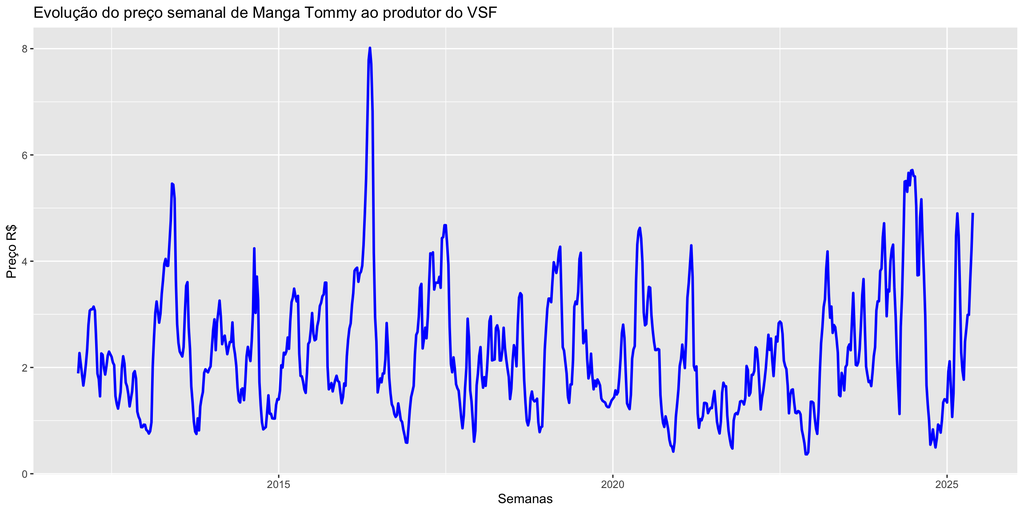

```r
#Direcionado o R para o Diretorio a ser trabalhado
setwd('/Users/jricardofl/Dropbox/tempecon/facape/econometria2')

#Inicio do Script

#Pacotes a serem usados
library(forecast)
library(ggplot2)
#library(easyGgplot2)
library(urca)
library(stargazer)
library(tseries)
library(lmtest)
library(ggthemes)
library(zoo)
library(xts)
library(FinTS)
library(scales)
library(uroot)
library(fGarch)
library(rugarch)
library(PerformanceAnalytics)
library(tsibbledata)
library(fable)
library(feasts)
library(fabletools)

options(digits=4)
#options(scipen = 999)
#options(scipen = 0)

#Extracao dos dados
dados <- read.csv2('dados_manga_tommy_semana.csv', header=T, sep=";", dec=".")
#dados <- dados[,-c(9:10)] #retirar as ultimas colunas
colnames(dados)[1]<-'produto'

#Entrando dados no R - Deflator
igpdi <- read.csv2('igpdi.csv',
                   header=T, sep=";",
                   dec=".")

#Juntando as duas bases de dados
dados_comb<-cbind(dados, igpdi)

#Retira variaveis desnecessarias
dadost<-dados_comb[,-c(1,2,6,7)]

#Deflacionar a serie de manga
dadost$preco_def <- dadost[,3]*(tail(dadost[,4],1)/dadost[,4])


#Analise de Serie Temporal
preco_tommy <- dadost[,5]

#Setando como serie temporal
preco_tommy <- ts(preco_tommy, start=c(2012,1), freq=52)

#Grafico da Série
autoplot(preco_tommy, main='Evolução do preço semanal de Manga Tommy ao produtor do VSF') +
  geom_line(colour="blue", size=1.0) + xlab('Semanas')+ ylab('Preço R$')
```

## Transformação em dados mensais

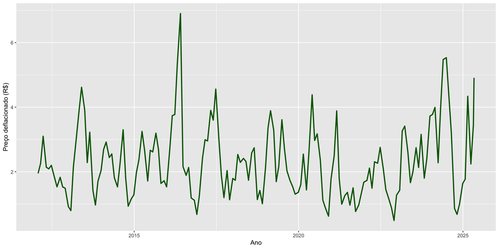

```r
# Converter preco_tommy (ts) em xts com datas semanais
datas_semanais <- seq.Date(from = as.Date("2012-01-01"), by = "week", length.out = length(preco_tommy))
serie_xts <- xts(preco_tommy, order.by = datas_semanais)

# Agregar para média mensal
serie_mensal <- apply.monthly(serie_xts, mean)
colnames(serie_mensal) <- "preco_mensal"

serie_mensal_ts <- ts(as.numeric(serie_mensal), start = c(2012, 1), frequency = 12)

# Visualizar o gráfico
autoplot(serie_mensal, main = "Preço Médio Mensal da Manga Tommy - VSF") +
  geom_line(color = "darkgreen", size = 1) +
  xlab("Ano") + ylab("Preço deflacionado (R$)")
```

## Análise da Raiz Unitária

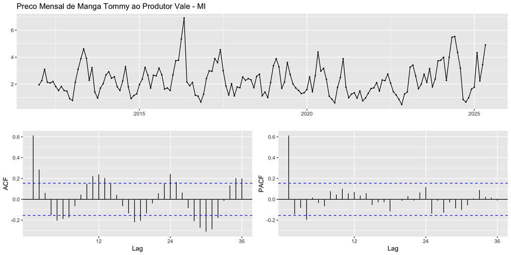

```r
#Visualizando as correlações das series
#INICIO DAS ANALISES PARA PREVISÃO
ggtsdisplay(serie_mensal_ts, main='Preco Mensal de Manga Tommy ao Produtor Vale - MI')
```

```r
#Teste de Raiz Unitaria na Serie
#Verificacao da Estacionariedade das s?ries
#Teste de raiz unitaria DF-GLS
#Defini??o do numero m?ximo de lags
print(12*(length(serie_mensal_ts)/100)^(1/4))
```

```
[1] 13.52
```

```r
#Estatistica de Teste DFGLS para preco_tommy
serie_mensal_tsT.dfgls <- ur.ers(serie_mensal_ts, type = c("DF-GLS"),
                      model = c("trend"),
                      lag.max = 9)
summary(serie_mensal_tsT.dfgls)
```

```
###############################################
# Elliot, Rothenberg and Stock Unit Root Test #
###############################################

Test of type DF-GLS
detrending of series with intercept and trend


Call:
lm(formula = dfgls.form, data = data.dfgls)

Residuals:
   Min     1Q Median     3Q    Max
-3.053 -0.638 -0.195  0.530  2.500

Coefficients:
             Estimate Std. Error t value Pr(>|t|)
yd.lag       -0.35055    0.12634   -2.77   0.0063 **
yd.diff.lag1  0.07256    0.13174    0.55   0.5826
yd.diff.lag2 -0.03632    0.12737   -0.29   0.7760
yd.diff.lag3 -0.00397    0.11893   -0.03   0.9734
yd.diff.lag4 -0.15254    0.11528   -1.32   0.1879
yd.diff.lag5 -0.12916    0.10938   -1.18   0.2397
yd.diff.lag6 -0.04984    0.10102   -0.49   0.6225
yd.diff.lag7 -0.20602    0.09585   -2.15   0.0333 *
yd.diff.lag8 -0.09943    0.09074   -1.10   0.2751
yd.diff.lag9 -0.16341    0.08903   -1.84   0.0685 .
---
Signif. codes:  0 '***' 0.001 '**' 0.01 '*' 0.05 '.' 0.1 ' ' 1

Residual standard error: 0.887 on 141 degrees of freedom
Multiple R-squared:  0.241, Adjusted R-squared:  0.187
F-statistic: 4.48 on 10 and 141 DF,  p-value: 1.74e-05


Value of test-statistic is: -2.775

Critical values of DF-GLS are:
                 1pct  5pct 10pct
critical values -3.46 -2.93 -2.64
```

```r
#Teste de Raiz Unitaria Sazonal HEGY
hegy.test(serie_mensal_ts, deterministic = c(1,1,0), lag.method = "AIC")
```

```
    HEGY test for unit roots

data:  serie_mensal_ts

        statistic p-value
t_1         -2.47    0.24
t_2         -2.62    0.01 **
F_3:4        3.13    0.05 *
F_5:6        8.64       0 ***
F_7:8       12.44       0 ***
F_9:10       8.33       0 ***
F_11:12      14.4       0 ***
F_2:12      17.88       0 ***
F_1:12      16.74       0 ***
---
Signif. codes: 0 '***' 0.001 '**' 0.01 '*' 0.05 '.' 0.1 ' ' 1

Deterministic terms: constant + trend
Lag selection criterion and order: AIC, 0
P-values: based on response surface regressions
```

## Estimação do Modelo ARIMA e verificação de ARCH

```r
#Estimacao do Modelo Auto-ARIMA
auto.arima <- auto.arima(serie_mensal_ts, max.p=10, max.d=1, max.D=1, max.q=10, max.P=10, max.Q=10,
                         seasonal = T, trace = TRUE)
```

```
 Fitting models using approximations to speed things up...

 ARIMA(2,0,2)(1,0,1)[12] with non-zero mean : Inf
 ARIMA(0,0,0)            with non-zero mean : 495.9
 ARIMA(1,0,0)(1,0,0)[12] with non-zero mean : 427
 ARIMA(0,0,1)(0,0,1)[12] with non-zero mean : 428.8
 ARIMA(0,0,0)            with zero mean     : 761.7
 ARIMA(1,0,0)            with non-zero mean : 419.7
 ARIMA(1,0,0)(0,0,1)[12] with non-zero mean : 419.9
 ARIMA(1,0,0)(1,0,1)[12] with non-zero mean : Inf
 ARIMA(2,0,0)            with non-zero mean : 418.8
 ARIMA(2,0,0)(1,0,0)[12] with non-zero mean : 425.6
 ARIMA(2,0,0)(0,0,1)[12] with non-zero mean : 419.2
 ARIMA(2,0,0)(1,0,1)[12] with non-zero mean : Inf
 ARIMA(3,0,0)            with non-zero mean : 419.8
 ARIMA(2,0,1)            with non-zero mean : 417.1
 ARIMA(2,0,1)(1,0,0)[12] with non-zero mean : 423.3
 ARIMA(2,0,1)(0,0,1)[12] with non-zero mean : 418.1
 ARIMA(2,0,1)(1,0,1)[12] with non-zero mean : Inf
 ARIMA(1,0,1)            with non-zero mean : 418.6
 ARIMA(3,0,1)            with non-zero mean : 420.5
 ARIMA(2,0,2)            with non-zero mean : 418.8
 ARIMA(1,0,2)            with non-zero mean : 420.4
 ARIMA(3,0,2)            with non-zero mean : 421.9
 ARIMA(2,0,1)            with zero mean     : Inf

 Now re-fitting the best model(s) without approximations...

 ARIMA(2,0,1)            with non-zero mean : 415.9

 Best model: ARIMA(2,0,1)            with non-zero mean
```

```r
summary(auto.arima)
```

```
Series: serie_mensal_ts
ARIMA(2,0,1) with non-zero mean

Coefficients:
        ar1     ar2     ma1   mean
      1.326  -0.544  -0.617  2.311
s.e.  0.145   0.094   0.152  0.118

sigma^2 = 0.742:  log likelihood = -202.7
AIC=415.5   AICc=415.9   BIC=430.9

Training set error measures:
                   ME   RMSE   MAE    MPE  MAPE   MASE    ACF1
Training set 0.001108 0.8508 0.662 -14.95 34.55 0.6509 -0.0117
```

```r
coeftest(auto.arima)
```

```
z test of coefficients:

          Estimate Std. Error z value Pr(>|z|)
ar1         1.3257     0.1453    9.12  < 2e-16 ***
ar2        -0.5445     0.0942   -5.78  7.6e-09 ***
ma1        -0.6168     0.1520   -4.06  4.9e-05 ***
intercept   2.3109     0.1180   19.59  < 2e-16 ***
---
Signif. codes:  0 '***' 0.001 '**' 0.01 '*' 0.05 '.' 0.1 ' ' 1
```

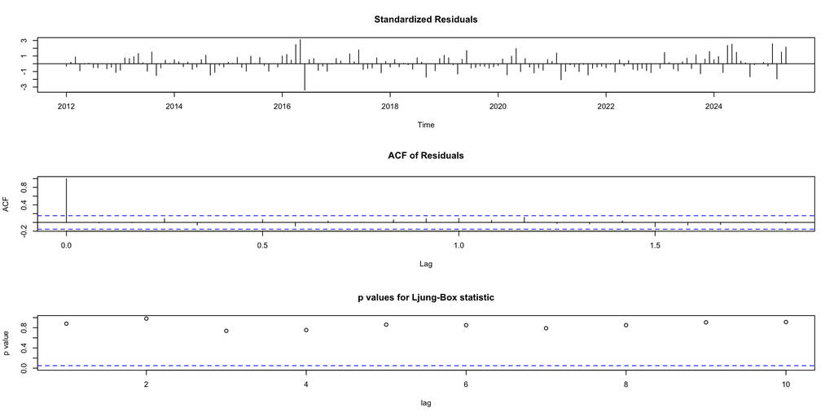

```r
tsdiag(auto.arima)
```

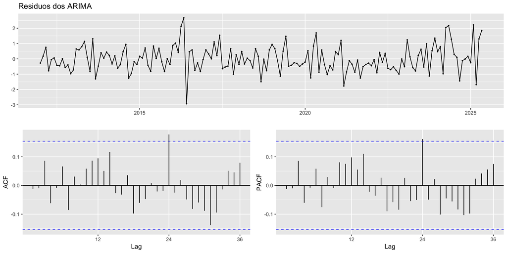

```r
#Visualizando a correlação dos resíduos
ggtsdisplay(auto.arima$residuals, main='Residuos dos ARIMA')
```

```r
#Teste de Ljung Box para autocorrelação nos resíduos
#Hipotese nula do teste é que os residuos nao sao autocorrelacionados
Box.test(auto.arima$residuals, lag=40,
         type="Ljung-Box", fitdf=length(coef(auto.arima)))
```

```
    Box-Ljung test

data:  auto.arima$residuals
X-squared = 35, df = 36, p-value = 0.5
```

```r
#Teste para verificar se os residuos seguem ARCH
#H0: Não existe efeito ARCH
ArchTest(auto.arima$residuals, lags = 1, demean = TRUE)
```

```
    ARCH LM-test; Null hypothesis: no ARCH effects

data:  auto.arima$residuals
Chi-squared = 34, df = 1, p-value = 7e-09
```

# Estimação do modelo ARCH

```r
residuos_arima <- residuals(auto.arima)

arch01 <- garch(residuos_arima, order = c(0,1), trace=FALSE)
arch02 <- garch(residuos_arima, order = c(0,2), trace=FALSE)
arch03 <- garch(residuos_arima, order = c(0,3), trace=FALSE)
garch11 <- garch(residuos_arima, order = c(1,1), trace=FALSE)
garch22 <- garch(residuos_arima, order = c(2,2), trace=FALSE)

#Escolha do modelo ARCH com AICc -
N <- length(serie_mensal_ts)
loglik0 <- -0.5 * N * (1 + log(2 * pi * mean(auto.arima$residuals^2)))
loglik1 <- logLik(arch01)
loglik2 <- logLik(arch02)
loglik3 <- logLik(arch03)
loglik4 <- logLik(garch11)
loglik5 <- logLik(garch22)

loglik <- c(loglik0, loglik1, loglik2, loglik3, loglik4, loglik5)
q <- c(0, 1, 2, 3, 4, 5)
k <- q + 1
aicc <- -2 * loglik  + 2 * k * N / (N - k - 1)
aicc
```

```
[1] 406.9 389.7 390.4 392.3 397.5 397.7
```

```r
#stargazer(print(data.frame(q, loglik, aicc)))

#Modelo Escolhido
fit.arch <- garch(auto.arima$residuals, c(0, 1), trace=FALSE)
summary(fit.arch)
```

```
Call:
garch(x = auto.arima$residuals, order = c(0, 1), trace = FALSE)

Model:
GARCH(0,1)

Residuals:
    Min      1Q  Median      3Q     Max
-2.1007 -0.6796 -0.0605  0.6660  3.0938

Coefficient(s):
    Estimate  Std. Error  t value Pr(>|t|)
a0    0.4954      0.0719     6.89  5.7e-12 ***
a1    0.2884      0.1360     2.12    0.034 *
---
Signif. codes:  0 '***' 0.001 '**' 0.01 '*' 0.05 '.' 0.1 ' ' 1

Diagnostic Tests:
    Jarque Bera Test

data:  Residuals
X-squared = 5.6, df = 2, p-value = 0.06


    Box-Ljung test

data:  Squared.Residuals
X-squared = 0.28, df = 1, p-value = 0.6
```

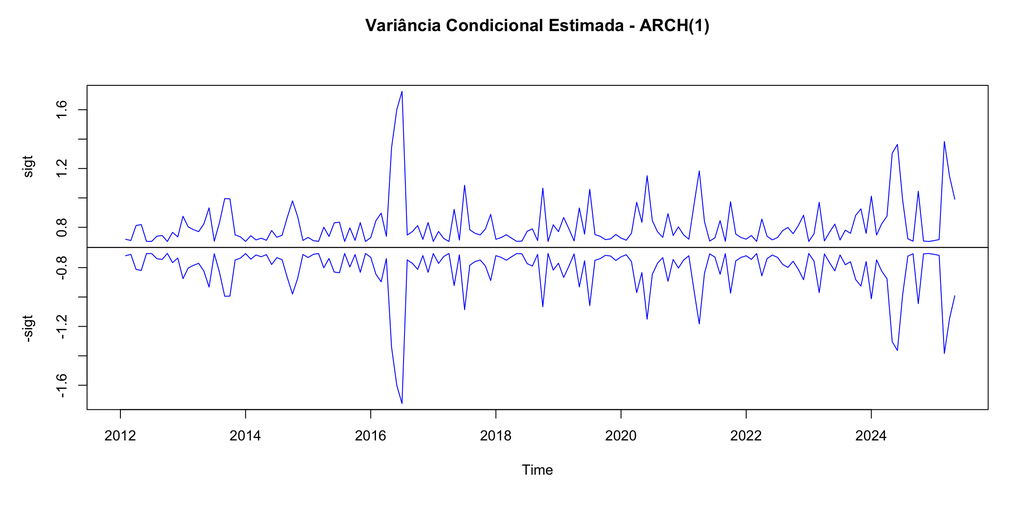

```r
plot.ts(fit.arch$fitted.values, main = "Variância Condicional Estimada - ARCH(1)", col = "blue")
```

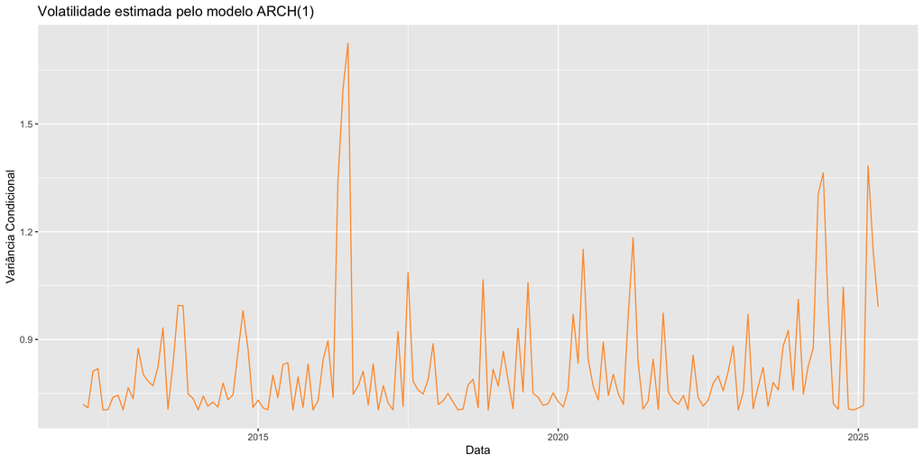

```r
# Extrair a coluna correta da matriz
variancia_estimada <- as.numeric(fit.arch$fitted.values[,1])

# Criar data frame com a variância condicional estimada corretamente
df_vol <- data.frame(
  date = seq.Date(as.Date("2012-01-01"), by = "month", length.out = length(residuos_arima)),
  resid = residuos_arima,
  ht = variancia_estimada # CORRETO para tseries::garch()
)

# Gráfico da variância condicional
ggplot(df_vol, aes(x = date, y = ht)) +
  geom_line(col = '#ff9933') +
  ylab('Variância Condicional') +
  xlab('Data') +
  ggtitle('Volatilidade estimada pelo modelo ARCH(1)')
```

Claramente, há períodos com picos de volatilidade, o que é característico de séries com *volatility clustering* — justamente o que o modelo ARCH(1) busca capturar. O gráfico apresenta agrupamentos de alta volatilidade, com destaque para: a) Um pico ao redor de 2016; b) Outros picos entre 2018–2020; c) E uma sequência forte de aumentos em 2024 e início de 2025.

Esses episódios são plausíveis para séries de preços agrícolas, que podem refletir: problemas climáticos, quebra de safra, mudanças cambiais, entre outros choques.

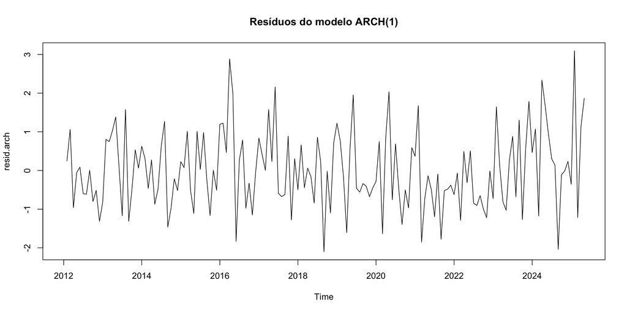

```r
# Diagnóstico com os resíduos do ARCH(1)
resid.arch <- residuals(fit.arch)
plot(resid.arch, type = "l", col = "black", main = "Resíduos do modelo ARCH(1)")
```

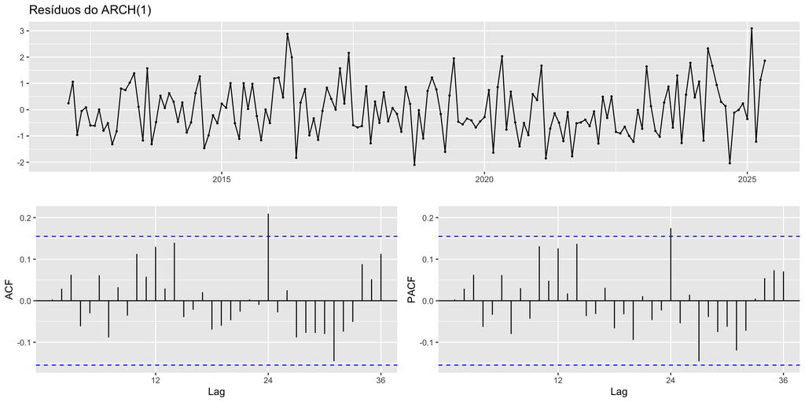

```r
# Verificar se os resíduos são ruído branco
ggtsdisplay(resid.arch, main = 'Resíduos do ARCH(1)')
```

Assim, os gráficos das funções de autocorrelação mostram que os resíduos se comportam como ruído branco. A maioria das autocorrelações está dentro das bandas de confiança (azul). Pequenos picos são esperados por acaso, mas nada persistente.

## Estimação do modelo ARCH - Retornos.

Neste caso, serão usados os retornos. Retornos são mais estacionários do que preços — o que facilita modelagem de média e variância. Volatilidade condicional faz mais sentido em séries de retornos, especialmente em ativos e preços de commodities. A maioria dos modelos ARCH/GARCH da literatura trabalha com $r_t = \log(P_t) - \log(P_{t-1})$.

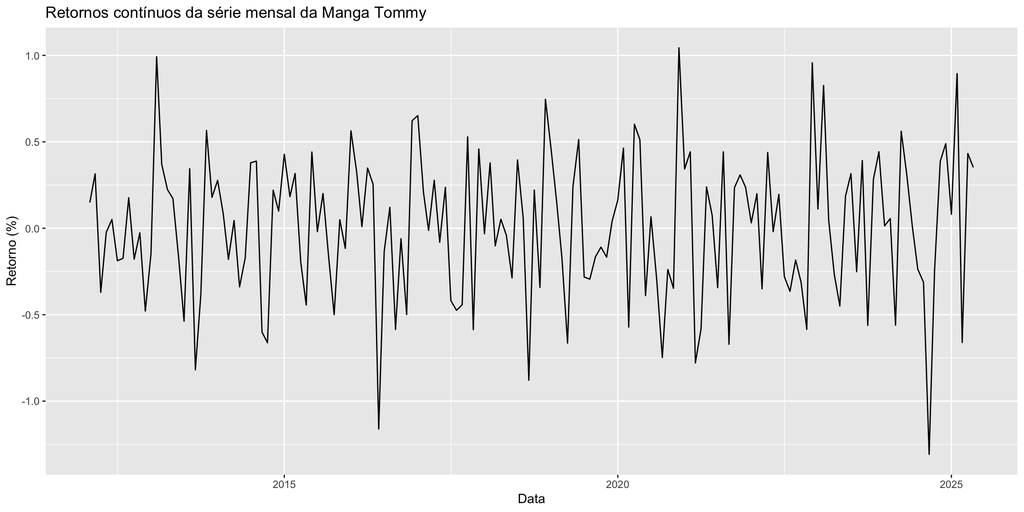

```r
# Garantir que serie_mensal_ts esteja numérica
serie_mensal_ts <- ts(as.numeric(serie_mensal), start = c(2012, 1), frequency = 12)

# Criar vetor de datas mensais (não semanais!)
date <- seq.Date(as.Date("2012-01-01"), by = "month", length.out = length(serie_mensal_ts))

# Transformar em objeto xts corretamente
serie_mensal_xts <- xts(serie_mensal_ts, order.by = date)

# Calcular retornos logarítmicos (contínuos) e remover NA inicial
retorno <- serie_mensal_xts |>
  PerformanceAnalytics::Return.calculate(method = "log") |>
  na.omit()

# Visualizar os retornos
autoplot(retorno) +
  ggtitle("Retornos contínuos da série mensal da Manga Tommy") +
  ylab("Retorno (%)") + xlab("Data")
```

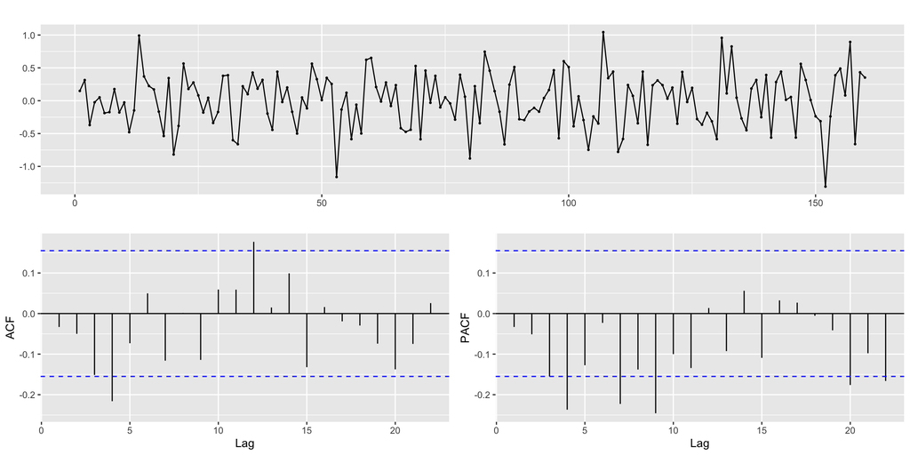

```r
retorno_quad = retorno^2

ggtsdisplay(retorno)
```

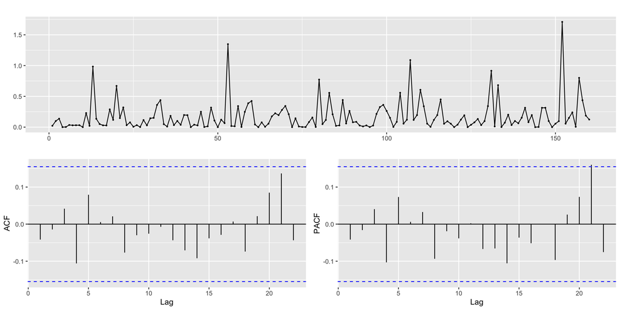

```r
ggtsdisplay(retorno_quad)
```

```r
# Verificaçao de retornos sao autocorrelacioandos
#H0: a série é distribuida de forma independente
#Ha> a serie apresenta correlaçao serial
Box.test(retorno, lag = 24, type = 'Ljung')
```

```
    Box-Ljung test

data:  retorno
X-squared = 58, df = 24, p-value = 1e-04
```

A hipótese de que os retornos são ruído branco (não autocorrelacionados) foi rejeitada com alto grau de confiança, mesmo considerando até 24 meses de defasagens. Em mercados agrícolas (como o de manga ao produtor), é comum observar alguma dependência intertemporal, por causa de: a) Sazonalidade da produção; Ciclos de exportação/demanda; Preços administrados ou defasados por contratos.

```r
#Verificacao da média do retorno se é igual a zero
#H0: media é igual a zero
t.test(as.vector(retorno))
```

```
    One Sample t-test

data:  as.vector(retorno)
t = 0.17, df = 159, p-value = 0.9
alternative hypothesis: true mean is not equal to 0
95 percent confidence interval:
 -0.05995  0.07149
sample estimates:
mean of x
 0.005771
```

Não há evidência estatística de que a média dos retornos seja diferente de zero. A hipótese de média zero não é rejeitada, mesmo com nível de 10% de significância.

Então, mesmo com média dos retornos igual a zero em média, não se deve assumir média constante e independente, porque há memória nos retornos (autocorrelação). Isso exige modelar a média condicional (ARIMA ou ao menos AR) antes da variância (GARCH).

```r
# Utilizar $aretono^2$ para verificar se existe heterocedasticidade condicional, o chamado **efeito ARCH**.

y <- retorno - mean(retorno)
y_quad <- y^2
Box.test(y_quad, lag = 24, type = 'Ljung')
```

```
    Box-Ljung test

data:  y_quad
X-squared = 17, df = 24, p-value = 0.9
```

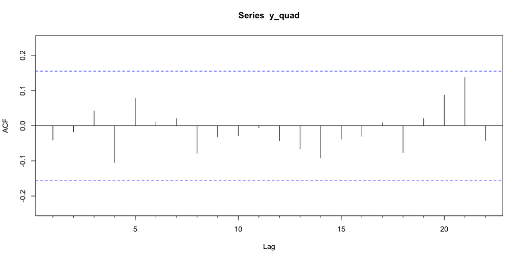

```r
forecast::Acf(y_quad)
```

Como o p-valor é muito alto (0,90), não há evidência de autocorrelação nos quadrados dos retornos. Isto significa que não há heterocedasticidade condicional detectável nos retornos logarítmicos mensais da série da manga Tommy.

Isto indica que provavelmente não será necessário estimar um modelo ARCH/GARCH, porque a variância condicional dos retornos parece constante ao longo do tempo.

## Estimação do modelo ARCH - 2 Forma

O modelo pode ser construído por meio do pacote `rugarch` em duas etapas:

- Especificação do modelo com a função `ugarchspec`
- Estimação com a função `ugarchfit`

Na primeira etapa, os critérios devem ser escolhidos:

- `mean.model`: uma lista contendo a ordem do modelo ARMA e se há a inclusão ou não de um modelo para a média (A escolha da ordem 0,0 define uma média constante)
- `variance.model`: uma lista contendo o tipo do modelo e a ordem do modelo. Note que `sGARCH` significa `standard` e (1,0) define um modelo `ARCH`.
- `distribution.model`: o tipo de distribuição escolhido no modelo. Neste caso, as opções são: norm (Normal), std (t), ged (Distribuição dos erros generalizada), snorm, sstd e sged, quando se tem assimetria e ghyp (Hiperbólica Generalizada).

Para cada parâmetro existe uma opção definida de acordo com a liteturatura conhecida do modelo, seja a escolha da estimação da média, da variância e da distribuição. Para mais detalhes, é necessário ler a documentação usando `?ugarchespec`.

Definido a especificação do modelo, é necessário estimar utilizando `ugarchfit`, em que os dois parâmetros mais importantes são `data` para dados (a classe deve ser numeric vector, matrix, data.frame, zoo, xts, timeSeries, ts ou irts) e `spec` para especificação.

```r
archspec <- rugarch::ugarchspec(
  mean.model = list(armaOrder = c(4, 0), include.mean = TRUE), # ajuste conforme seu ARIMA(4,0,0)
  variance.model = list(model = "sGARCH", garchOrder = c(1, 0)),
  distribution.model = "norm"
)

archfit <- rugarch::ugarchfit(data = serie_mensal_ts, spec = archspec)

archfit
```

```
*---------------------------------*
*          GARCH Model Fit        *
*---------------------------------*

Conditional Variance Dynamics
-----------------------------------
GARCH Model : sGARCH(1,0)
Mean Model  : ARFIMA(4,0,0)
Distribution    : norm

Optimal Parameters
------------------------------------
        Estimate  Std. Error   t value Pr(>|t|)
mu      2.221741    0.099296 22.374877 0.000000
ar1     0.754076    0.087355  8.632349 0.000000
ar2    -0.151122    0.082776 -1.825681 0.067898
ar3    -0.002218    0.083582 -0.026531 0.978834
ar4    -0.177042    0.070212 -2.521537 0.011684
omega   0.443320    0.073844  6.003502 0.000000
alpha1  0.373980    0.143099  2.613440 0.008964

Robust Standard Errors:
        Estimate  Std. Error  t value Pr(>|t|)
mu      2.221741    0.104277 21.30622 0.000000
ar1     0.754076    0.075314 10.01240 0.000000
ar2    -0.151122    0.060054 -2.51644 0.011855
ar3    -0.002218    0.072020 -0.03079 0.975437
ar4    -0.177042    0.063667 -2.78074 0.005423
omega   0.443320    0.071097  6.23546 0.000000
alpha1  0.373980    0.106428  3.51391 0.000442

LogLikelihood : -190.6

Information Criteria
------------------------------------

Akaike       2.4549
Bayes        2.5889
Shibata      2.4514
Hannan-Quinn 2.5093
```

[output cut: 45 more lines]

```
Negative Sign Bias 0.81949 0.4138
Positive Sign Bias 0.80867 0.4199
Joint Effect       2.88736 0.4093


Adjusted Pearson Goodness-of-Fit Test:
------------------------------------
  group statistic p-value(g-1)
1    20     13.29       0.8236
2    30     22.54       0.7971
3    40     30.06       0.8474
4    50     39.31       0.8373


Elapsed time : 1.278
```

```r
coef(archfit)
```

```
       mu       ar1       ar2       ar3       ar4     omega    alpha1
 2.221741  0.754076 -0.151122 -0.002218 -0.177042  0.443320  0.373980
```

No modelo ajustado:

No caso de *Weighted Ljung-Box Test on Standardized Residuals*, o objetivo aqui é verificar se os resíduos padronizados do modelo ARCH(1) ainda apresentam autocorrelação serial, o que não deveria acontecer se o modelo está bem especificado. A $H_0$ é que os resíduos não têm autocorrelação (ou seja, são ruído branco). Todos os p-valores são bem maiores que 0,10, o que significa que não se rejeita $H_0$ em nenhum caso. Portanto, não há autocorrelação nos resíduos padronizados do modelo ARCH(1) estimado.

O Nyblom Teste avalia se os parametros são estáveis (constantes) ao longo do tempo. Como o valor crítico a 10% é 1,69 e todos os valores das estatisticas individuais estão abaixo deste valor, todos os parâmetros são estáveis. Com isto, se pode confiar nas previsões e inferências.

O Sign Test (proposto por Engle e Ng (1993)) é um teste muito útil para detectar assimetria na forma como choques positivos e negativos afetam a volatilidade, algo que os modelos ARCH/GARCH padrão não capturam diretamente. A $H_0$ é que não há viés de sinal — choques positivos e negativos têm o mesmo impacto na volatilidade. Os resultados não apresentaram assimetrias no impacto dos choques sobre a volatilidade. Com isto, não se tem a necessidade de estimar um modelo TARCH, por exemplo.

Finalmente, o teste de aderencia (Adjusted Pearson Goodness of fit test) é um teste de aderência do modelo aos dados, especificamente projetado para avaliar se os resíduos padronizados do modelo seguem a distribuição assumida (Normal). É um teste de normalidade. Os resultados mostram que não rejeitamos a Hipotese nula, ou seja, os resíduos seguem a distribuição Normal.

## Previsão do modelo ARCH

```r
# Previsão Fora da Amostra
archforecast <- ugarchforecast(fitORspec = archfit, n.ahead = 4)

sigma(archforecast)
```

```
    Mai 2025
T+1   1.2285
T+2   1.0039
T+3   0.9056
T+4   0.8661
```

As previsões são para os próximos 4 meses após o último ponto da amostra. Essa função retorna os desvios padrões condicionais previstos, ou seja, a volatilidade esperada para cada mês futuro. A volatilidade esperada diminui mês a mês. Isso indica que, segundo o modelo ARCH(1), o impacto do último grande choque está se dissipando, e a série deve entrar num período de menor incerteza. Em termos econômicos, você está prevendo que os preços da manga Tommy estarão menos voláteis nos próximos quatro meses.

# Estimação de Modelo ARCH no Python

## Entrada dos dados

```python
# Bibliotecas
import pandas as pd
import numpy as np
import plotnine as p9
from pathlib import Path
from arch.unitroot import DFGLS
from statsmodels.graphics.tsaplots import plot_acf, plot_pacf
import matplotlib.pyplot as plt
import pmdarima as pm
from statsmodels.stats.diagnostic import het_arch
from statsmodels.tsa.statespace.sarimax import SARIMAX
from statsmodels.stats.diagnostic import acorr_ljungbox
from arch import arch_model
from scipy.stats import jarque_bera
import statsmodels.api as sm

# Configuração de precisão nos números
#pd.set_option("display.precision", 4)

# Caminho do diretório de trabalho
data_dir = Path("/Users/jricardofl/Dropbox/tempecon/facape/econometria2")

# Load mango price dataset and drop specified columns
df = (
    pd.read_csv(data_dir/'dados_manga_tommy_semana.csv', sep=';', decimal='.')
    .drop(columns=['produto', 'regiao', 'ano', 'semana'])
)

# Create the date range from 2012-01-07 to today
date_range = pd.date_range(start='2012-01-01', end=pd.Timestamp.today(), freq='W-SAT')

# Remove the specific dates (53rd weeks)
dates_to_remove = [pd.Timestamp('2016-12-31'), pd.Timestamp('2022-12-31')]
date_range = date_range[~date_range.isin(dates_to_remove)]
date_range = date_range[:len(df)]

# Assign the date range as a new column
df['date'] = date_range
# Assign the date range as a new column
df['date2'] = date_range[:len(df)]

# Set the date as the index
df = df.set_index('date')

# Carregar o dataset igpdi
igpdi = (
    pd.read_csv(data_dir/'igpdi.csv', sep=';', decimal='.')
    .assign(date=df.index)
    .drop(columns=['ano', 'semana'])
    .set_index('date')
)

# Juntar os DataFrames
tabela = df.join(igpdi, how='inner')

# Deflacionar a série com data base = último mês observado
indice_data_base = tabela.query("date == date.max()").igpdi.values[0]
tabela = tabela.assign(real = lambda x: (indice_data_base / x.igpdi) * x.preco)

# Criação da variável preco_palmer
dadost = tabela['real']
```

## Gráfico da série semanal

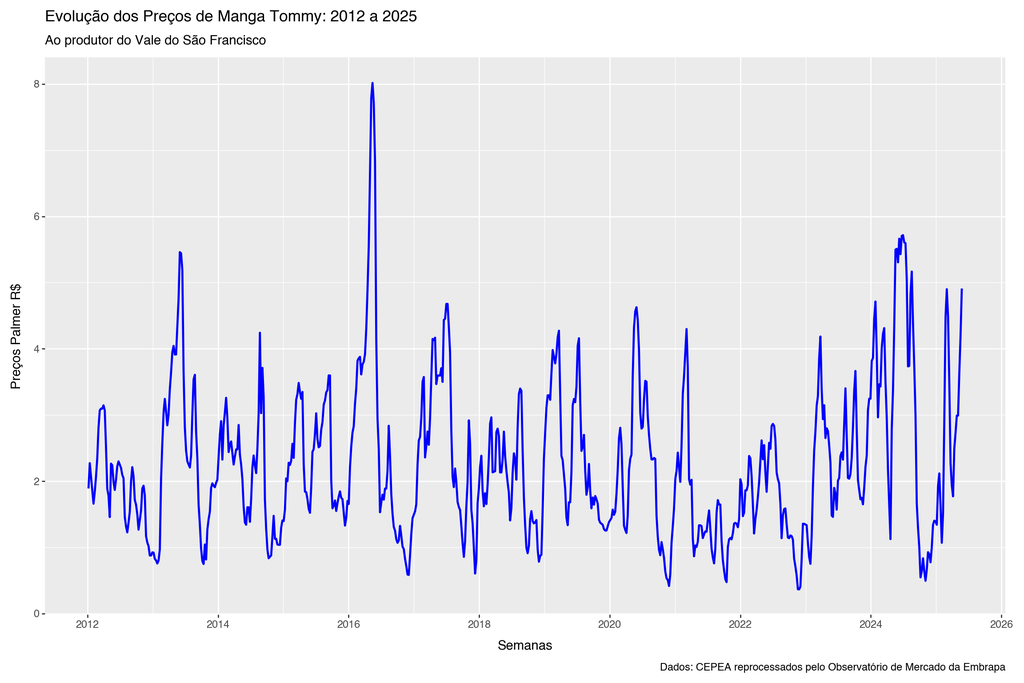

```python
# Visualização de dados
plot = (
  p9.ggplot(tabela) +
  p9.aes(x = "date2", y = "real") +
  p9.geom_line(colour="blue", size=1.0) +
  p9.scale_x_date(date_breaks = "2 year", date_labels = "%Y") +
  p9.labs(
    title = "Evolução dos Preços de Manga Tommy: 2012 a 2025",
    subtitle = "Ao produtor do Vale do São Francisco",
    x = "Semanas",
    y = "Preços Palmer R$",
    caption = "Dados: CEPEA reprocessados pelo Observatório de Mercado da Embrapa"
    )+
    p9.theme(
        figure_size=(12, 8)
        )
)

plot.show()
```

## Gráfico da Série mensal

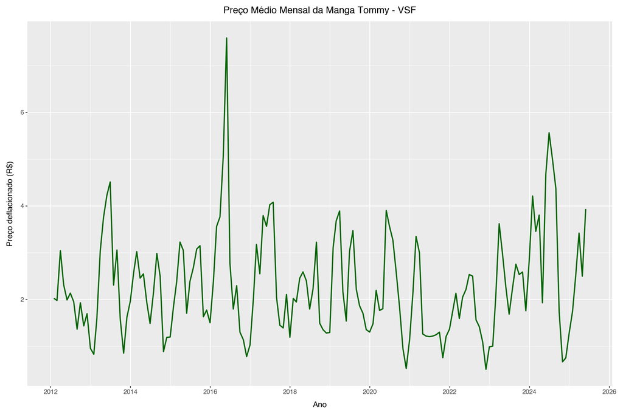

```python
# Criar a série semanal com index já ajustado (já feito anteriormente)
serie_xts = dadost.copy()  # dadost é a série 'real' deflacionada, com índice semanal (date)

# Agregar por média mensal
serie_mensal = (
    serie_xts
    .resample('ME')
    .mean()
    .rename("preco_mensal")
    .to_frame()
    .reset_index()
)

# Visualizar com plotnine
grafico_mensal = (
    p9.ggplot(serie_mensal) +
    p9.aes(x='date', y='preco_mensal') +
    p9.geom_line(color='darkgreen', size=1) +
    p9.scale_x_date(date_breaks = "2 year", date_labels = "%Y") +
    p9.labs(
        title='Preço Médio Mensal da Manga Tommy - VSF',
        x='Ano',
        y='Preço deflacionado (R$)'
    ) +
    p9.theme(
        figure_size=(12, 8)
        )
)

grafico_mensal.show()
```

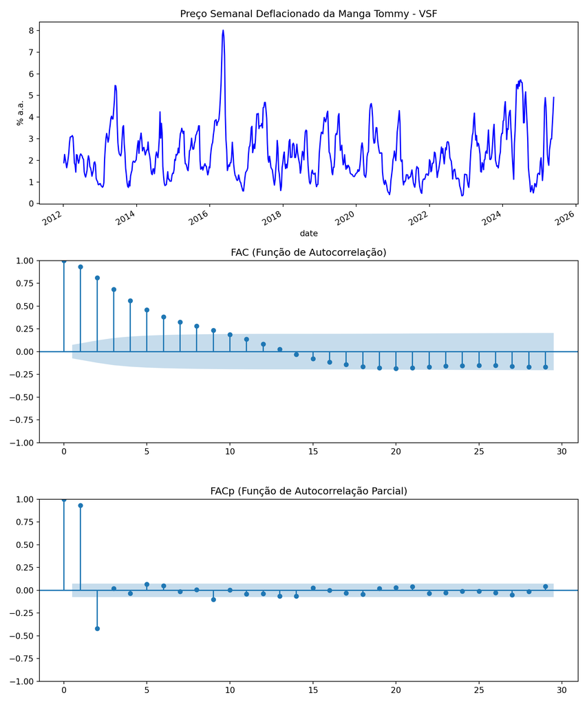

```python
# Plota IPCA, FAC, e FACpa
fig, axes = plt.subplots(3, 1, figsize=(10, 12))

# Plota IPCA
dadost.plot(ax=axes[0], title='Preços Tommy', color='blue')
axes[0].set_title('Preço Semanal Deflacionado da Manga Tommy - VSF')
axes[0].set_ylabel('% a.a.')

# Plota FAC
plot_acf(dadost, ax=axes[1], title='FAC (Função de Autocorrelação)')

# Plota FACp
plot_pacf(dadost, ax=axes[2], title='FACp (Função de Autocorrelação Parcial)', method='ywm')

plt.tight_layout()
plt.show()
```

```python
# Executa o teste DF-GLS com seleção automática de defasagens
dfgls_test1 = DFGLS(dadost, lags=None, trend='c')

# Exibe os resultados
print(dfgls_test1.summary())
```

```
      Dickey-Fuller GLS Results
=====================================
Test Statistic                 -5.787
P-value                         0.000
Lags                                4
-------------------------------------

Trend: Constant
Critical Values: -2.60 (1%), -1.97 (5%), -1.65 (10%)
Null Hypothesis: The process contains a unit root.
Alternative Hypothesis: The process is weakly stationary.
```

```python
# Executa o teste DF-GLS com seleção automática de defasagens
dfgls_test2 = DFGLS(dadost, lags=None, trend='ct')

# Exibe os resultados
print(dfgls_test2.summary())
```

```
      Dickey-Fuller GLS Results
=====================================
Test Statistic                 -6.001
P-value                         0.000
Lags                                4
-------------------------------------

Trend: Constant and Linear Time Trend
Critical Values: -3.44 (1%), -2.88 (5%), -2.59 (10%)
Null Hypothesis: The process contains a unit root.
Alternative Hypothesis: The process is weakly stationary.
```

O Python não tem o teste HEGY de raiz unitária sazonal.

### Estimação do ARIMA no Python com os dados semanais

```python
# Série semanal deflacionada (em vez da mensal, já que você decidiu voltar aos dados semanais)
# Se ainda quiser usar a mensal, substitua `y` por `serie_mensal['preco_mensal']`
y = tabela['real'].dropna()

# Estimar modelo auto-ARIMA
#modelo_arima = pm.auto_arima(
#    y,
#    start_p=0, start_q=0,
#    max_p=4, max_q=4,
#    max_d=1,
#    seasonal=True,
#    m=52,  # frequência semanal
#    max_P=3, max_Q=3, max_D=1,
#    trace=True,
#    stepwise=True,
#    suppress_warnings=True,
#    information_criterion='aic',
#    error_action='ignore'
#)

modelo_sarimax = SARIMAX(
    y,
    order=(2, 0, 0),
    seasonal_order=(3, 0, 0, 52),
    enforce_stationarity=False,
    enforce_invertibility=False
)


# Resumo do modelo
ajuste_modelo = modelo_sarimax.fit(disp=False)
print(ajuste_modelo.summary())
```

```
                                     SARIMAX Results
==========================================================================================
Dep. Variable:                               real   No. Observations:                  697
Model:             SARIMAX(2, 0, 0)x(3, 0, 0, 52)   Log Likelihood                -256.041
Date:                            Seg, 26 Mai 2025   AIC                            524.082
Time:                                    11:01:39   BIC                            549.820
Sample:                                         0   HQIC                           534.149
                                            - 697
Covariance Type:                              opg
==============================================================================
                 coef    std err          z      P>|z|      [0.025      0.975]
------------------------------------------------------------------------------
ar.L1          1.4153      0.034     41.594      0.000       1.349       1.482
ar.L2         -0.4436      0.033    -13.268      0.000      -0.509      -0.378
ar.S.L52       0.0930      0.050      1.878      0.060      -0.004       0.190
ar.S.L104      0.0654      0.052      1.256      0.209      -0.037       0.167
ar.S.L156      0.0971      0.042      2.305      0.021       0.015       0.180
sigma2         0.1514      0.006     23.741      0.000       0.139       0.164
===================================================================================
Ljung-Box (L1) (Q):                   1.01   Jarque-Bera (JB):               297.60
Prob(Q):                              0.32   Prob(JB):                         0.00
Heteroskedasticity (H):               1.11   Skew:                            -0.46
Prob(H) (two-sided):                  0.47   Kurtosis:                         6.52
===================================================================================

Warnings:
[1] Covariance matrix calculated using the outer product of gradients (complex-step).
```

Em seguida, os resíduos do ARIMA

```python
# Obter os resíduos do modelo ajustado
residuos_arima = ajuste_modelo.resid
```

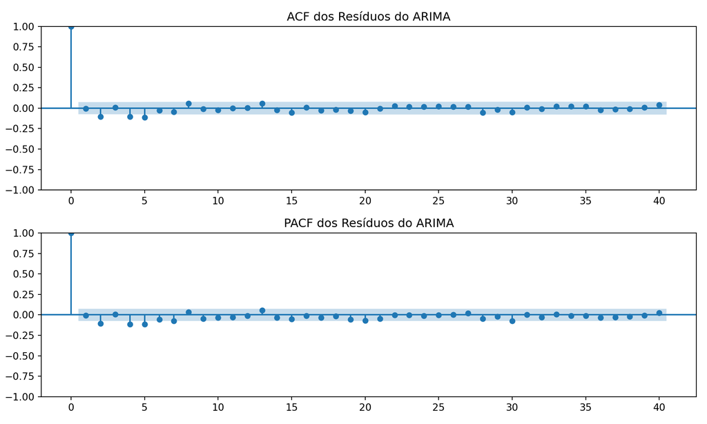

```python
fig, ax = plt.subplots(2, 1, figsize=(10, 6))
plot_acf(residuos_arima, lags=40, ax=ax[0])
plot_pacf(residuos_arima, lags=40, ax=ax[1])
ax[0].set_title("ACF dos Resíduos do ARIMA")
ax[1].set_title("PACF dos Resíduos do ARIMA")
plt.tight_layout()
plt.show()
```

```python
# Teste com múltiplas defasagens
ljungbox = acorr_ljungbox(residuos_arima, lags=[10, 20, 30], return_df=True)
print(ljungbox)
```

```
      lb_stat  lb_pvalue
10  29.019455   0.001237
20  37.337997   0.010656
30  43.687371   0.050895
```

O próximo passo é testar a presença de efeito ARCH nos resíduos

```python
# Teste ARCH-LM nos resíduos do ARIMA
arch_test = het_arch(residuos_arima, maxlag=12)

print(f'Estatística LM: {arch_test[0]:.4f}')
```

```
Estatística LM: 21.3381
```

```python
print(f'p-valor: {arch_test[1]:.4f}')
```

```
p-valor: 0.0456
```

Apesar de não rejeitar a hipótese nula de ausência de autocorrelação no primeiro Lag, nos lags mais altos se encontrou autocorrelação. Além disso, há heterocedasticidade (teste ARCH significativo) nos resíduos, indicando que o modelo ARCH/GARCH é o melhor caminho a se fazer.

### Escolha do melhor modelo ARCH/GARCH no Python com os dados semanais

```python
N = len(residuos_arima)
modelos = {}
aicc_values = {}

aicc_values = {}
modelos = {}

# Benchmark (sem GARCH)
loglik0 = -0.5 * N * (1 + np.log(2 * np.pi * np.mean(residuos_arima ** 2)))
aicc_values["modelo0"] = -2 * loglik0 + (2 * 1 * N) / (N - 1 - 1)

# Modelos ARCH puros
for i in range(1, 4):  # ARCH(1), ARCH(2), ARCH(3)
    try:
        modelo = arch_model(residuos_arima, vol='ARCH', p=i)
        resultado = modelo.fit(disp='off')
        loglik = resultado.loglikelihood
        k = i + 1  # número de parâmetros: i + constante
        aicc = -2 * loglik + (2 * k * N) / (N - k - 1)
        nome = f"arch0{i}"
        aicc_values[nome] = aicc
        modelos[nome] = resultado
    except Exception as e:
        print(f"Erro no modelo ARCH(0,{i}): {e}")
        aicc_values[f"arch0{i}"] = np.nan

# Modelos GARCH
for p, q in [(1,1), (2,2)]:
    try:
        modelo = arch_model(residuos_arima, vol='GARCH', p=p, q=q)
        resultado = modelo.fit(disp='off')
        loglik = resultado.loglikelihood
        k = p + q + 1
        aicc = -2 * loglik + (2 * k * N) / (N - k - 1)
        nome = f"garch{p}{q}"
        aicc_values[nome] = aicc
        modelos[nome] = resultado
    except Exception as e:
        print(f"Erro no modelo GARCH({p},{q}): {e}")
        aicc_values[f"garch{p}{q}"] = np.nan

# Ordenar e exibir
aicc_ordenado = dict(sorted(aicc_values.items(), key=lambda item: item[1]))
print("AICc por modelo:")
```

```
AICc por modelo:
```

```python
for nome, valor in aicc_ordenado.items():
    print(f"{nome}: {valor:.4f}")
```

```
garch11: 606.4590
garch22: 610.5112
arch03: 610.7093
arch02: 614.5679
arch01: 618.7812
modelo0: 667.3594
```

Assim, o modelo escolhido foi o GARCH 1,1, por ter o menor valor do critério de AIC modificado.

## Estimação do GARCH(1,1)

```python
# Estimar o modelo GARCH(1,1)
modelo_garch11 = arch_model(residuos_arima, vol='Garch', p=1, q=1)
ajuste_garch11 = modelo_garch11.fit(disp='off')

# Exibir resumo dos resultados
print(ajuste_garch11.summary())
```

```
                     Constant Mean - GARCH Model Results
==============================================================================
Dep. Variable:                   None   R-squared:                       0.000
Mean Model:             Constant Mean   Adj. R-squared:                  0.000
Vol Model:                      GARCH   Log-Likelihood:               -300.212
Distribution:                  Normal   AIC:                           608.424
Method:            Maximum Likelihood   BIC:                           626.611
                                        No. Observations:                  697
Date:                Seg, Mai 26 2025   Df Residuals:                      696
Time:                        11:01:44   Df Model:                            1
                                 Mean Model
============================================================================
                 coef    std err          t      P>|t|      95.0% Conf. Int.
----------------------------------------------------------------------------
mu             0.0531  1.500e-02      3.541  3.981e-04 [2.372e-02,8.252e-02]
                              Volatility Model
============================================================================
                 coef    std err          t      P>|t|      95.0% Conf. Int.
----------------------------------------------------------------------------
omega          0.0422  1.885e-02      2.239  2.514e-02 [5.262e-03,7.914e-02]
alpha[1]       0.1938  9.165e-02      2.115  3.446e-02   [1.418e-02,  0.373]
beta[1]        0.5292      0.166      3.197  1.390e-03     [  0.205,  0.854]
============================================================================

Covariance estimator: robust
```

mu = 0.0531, significativo, indica que há um leve retorno médio nos resíduos, mas o foco do GARCH é a variância condicional. O parametro omega é a constante da variância estimada. O alpha[1] (efeito ARCH) é significativo e o beta[1] (efeito GARCH) também é. O efeito ARCH é para o impacto de choques recentes e o GARCH para a persistência na volatilidade.

Além disso, a soma alpha + beta = 0.1938 + 0.5292 ≈ 0.723, mostrando persistência moderada, mas inferior a 1, então o processo é estacionário em variância.

## Gráfico da variância condicional estimada ao longo do tempo

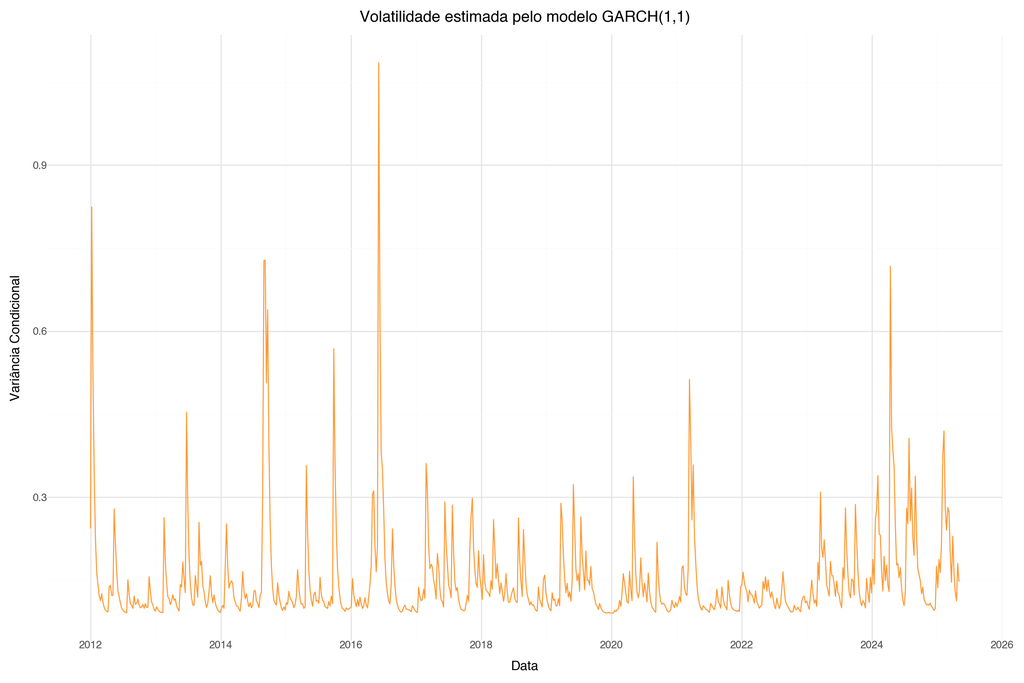

```python
# Criar DataFrame para visualização
df_vol = pd.DataFrame({
    "date": pd.date_range(start="2012-01-01", periods=len(residuos_arima), freq="W"),
    "resid": residuos_arima,
    "ht": ajuste_garch11.conditional_volatility ** 2
})

# Gráfico da variância condicional estimada
grafico = (
    p9.ggplot(df_vol, p9.aes(x="date", y="ht")) +
    p9.geom_line(color="#ff9933") +
    p9.labs(
        title="Volatilidade estimada pelo modelo GARCH(1,1)",
        x="Data",
        y="Variância Condicional"
    ) +
    p9.scale_x_date(date_breaks = "2 year", date_labels = "%Y") +
    p9.theme_minimal() +
    p9.theme(
        figure_size=(12, 8)
    )
)

grafico.show()
```

# Análise dos resíduos do GARCH(1,1)

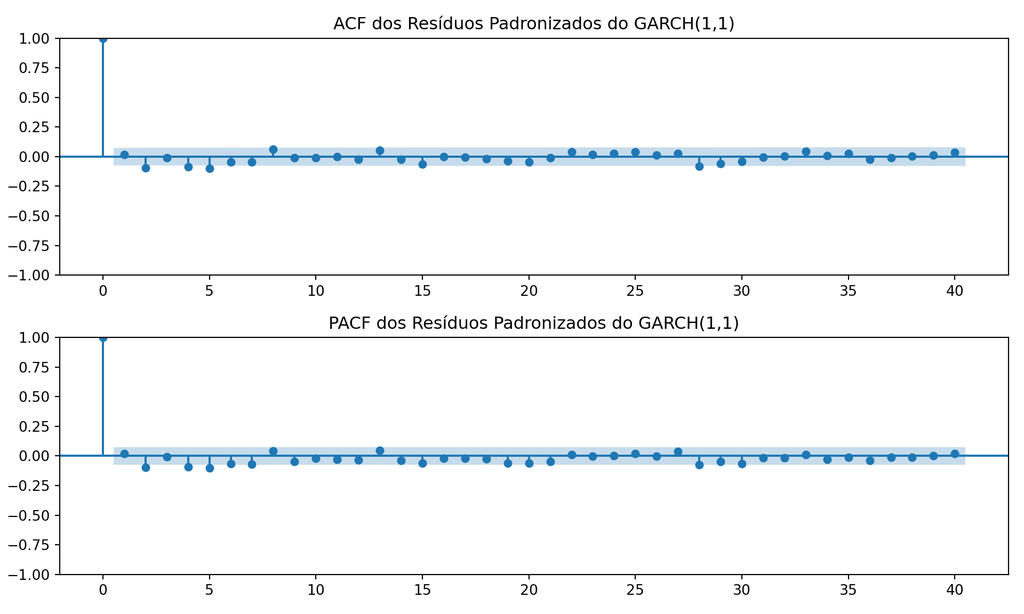

```python
# 1. Resíduos padronizados
residuos_padronizados = ajuste_garch11.std_resid

# 2. ACF e PACF
fig, ax = plt.subplots(2, 1, figsize=(10, 6))
plot_acf(residuos_padronizados.dropna(), lags=40, ax=ax[0])
plot_pacf(residuos_padronizados.dropna(), lags=40, ax=ax[1])
ax[0].set_title("ACF dos Resíduos Padronizados do GARCH(1,1)")
ax[1].set_title("PACF dos Resíduos Padronizados do GARCH(1,1)")
plt.tight_layout()
plt.show()
```

```python
# 3. Teste de Ljung-Box
ljungbox_garch = acorr_ljungbox(residuos_padronizados.dropna(), lags=[10, 20, 30], return_df=True)
print(ljungbox_garch)
```

```
      lb_stat  lb_pvalue
10  24.873553   0.005590
20  33.160726   0.032395
30  45.620997   0.033758
```

# Melhorar ajuste do GARCH

No primeiro caso, é estimado um modelo GARCH com distribuição t-Student:

```python
modelo_t = arch_model(residuos_arima, vol='Garch', p=1, q=1, dist='t')
ajuste_t = modelo_t.fit(disp='off')

print(ajuste_t.summary())
```

```
                        Constant Mean - GARCH Model Results
====================================================================================
Dep. Variable:                         None   R-squared:                       0.000
Mean Model:                   Constant Mean   Adj. R-squared:                  0.000
Vol Model:                            GARCH   Log-Likelihood:               -249.006
Distribution:      Standardized Student's t   AIC:                           508.011
Method:                  Maximum Likelihood   BIC:                           530.745
                                              No. Observations:                  697
Date:                      Seg, Mai 26 2025   Df Residuals:                      696
Time:                              11:01:48   Df Model:                            1
                                 Mean Model
============================================================================
                 coef    std err          t      P>|t|      95.0% Conf. Int.
----------------------------------------------------------------------------
mu             0.0594  1.121e-02      5.297  1.180e-07 [3.740e-02,8.133e-02]
                              Volatility Model
============================================================================
                 coef    std err          t      P>|t|      95.0% Conf. Int.
----------------------------------------------------------------------------
omega          0.0516  2.134e-02      2.416  1.568e-02 [9.735e-03,9.337e-02]
alpha[1]       0.2380  9.947e-02      2.393  1.672e-02   [4.307e-02,  0.433]
beta[1]        0.5098      0.148      3.439  5.838e-04     [  0.219,  0.800]
                              Distribution
========================================================================
                 coef    std err          t      P>|t|  95.0% Conf. Int.
------------------------------------------------------------------------
nu             3.2547      0.405      8.041  8.945e-16 [  2.461,  4.048]
========================================================================

Covariance estimator: robust
```

Neste caso, tem-se nu = 3.25, altamente significativo (p < 0.0001). Isto indica caudas pesadas: a distribuição dos resíduos tem muito mais extremos do que a normal. É uma melhoria substancial em relação ao modelo com distribuição normal.

O AIC foi 508.011, melhor que o GARCH(1,1) com normal (608.424).

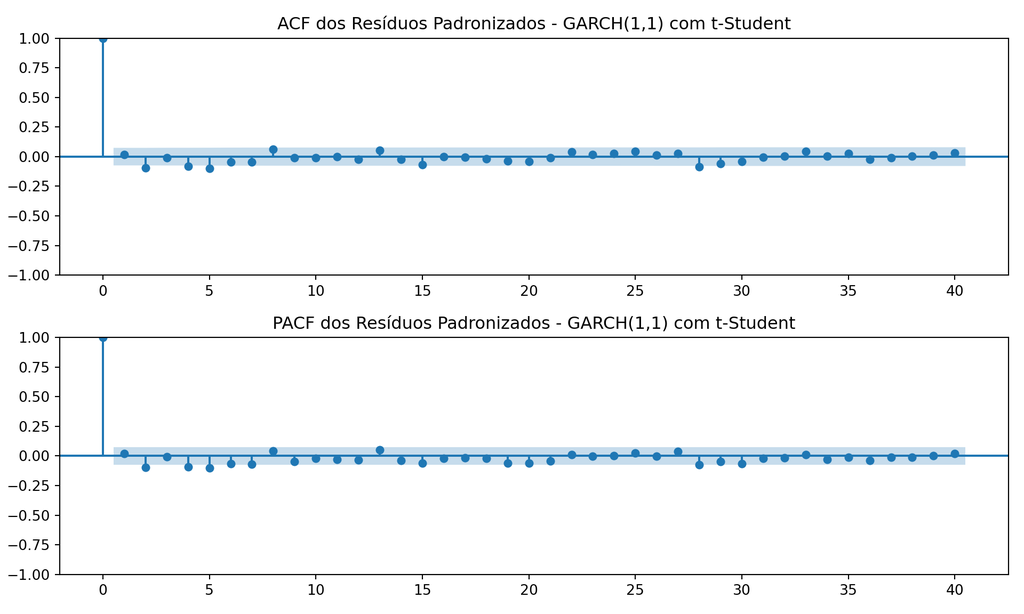

```python
# 1. Resíduos padronizados do modelo com distribuição t
residuos_padronizados_t = ajuste_t.std_resid.dropna()

# 2. ACF e PACF
fig, ax = plt.subplots(2, 1, figsize=(10, 6))
plot_acf(residuos_padronizados_t, lags=40, ax=ax[0])
plot_pacf(residuos_padronizados_t, lags=40, ax=ax[1])
ax[0].set_title("ACF dos Resíduos Padronizados - GARCH(1,1) com t-Student")
ax[1].set_title("PACF dos Resíduos Padronizados - GARCH(1,1) com t-Student")
plt.tight_layout()
plt.show()
```

```python
# 3. Teste de Ljung-Box
ljungbox_t = acorr_ljungbox(residuos_padronizados_t, lags=[10, 20, 30], return_df=True)
print(ljungbox_t)
```

```
      lb_stat  lb_pvalue
10  24.844228   0.005649
20  33.138531   0.032578
30  45.726251   0.032993
```

No segundo caso, é estimado um modelo GARCH com distribuição GED:

```python
modelo_ged = arch_model(residuos_arima, vol='Garch', p=1, q=1, dist='ged')
ajuste_ged = modelo_ged.fit(disp='off')

print(ajuste_ged.summary())
```

```
                           Constant Mean - GARCH Model Results
==========================================================================================
Dep. Variable:                               None   R-squared:                       0.000
Mean Model:                         Constant Mean   Adj. R-squared:                  0.000
Vol Model:                                  GARCH   Log-Likelihood:               -247.302
Distribution:      Generalized Error Distribution   AIC:                           504.604
Method:                        Maximum Likelihood   BIC:                           527.338
                                                    No. Observations:                  697
Date:                            Seg, Mai 26 2025   Df Residuals:                      696
Time:                                    11:01:50   Df Model:                            1
                                 Mean Model
============================================================================
                 coef    std err          t      P>|t|      95.0% Conf. Int.
----------------------------------------------------------------------------
mu             0.0445  3.943e-04    112.902      0.000 [4.375e-02,4.529e-02]
                              Volatility Model
============================================================================
                 coef    std err          t      P>|t|      95.0% Conf. Int.
----------------------------------------------------------------------------
omega          0.0410  1.669e-02      2.457  1.400e-02 [8.299e-03,7.372e-02]
alpha[1]       0.1954  7.802e-02      2.504  1.228e-02   [4.244e-02,  0.348]
beta[1]        0.5313      0.146      3.638  2.743e-04     [  0.245,  0.818]
                              Distribution
========================================================================
                 coef    std err          t      P>|t|  95.0% Conf. Int.
------------------------------------------------------------------------
nu             1.0176  6.743e-02     15.092  1.838e-51 [  0.885,  1.150]
========================================================================

Covariance estimator: robust
```

```python
residuos_padronizados_ged = ajuste_ged.std_resid.dropna()

ljungbox_ged = acorr_ljungbox(residuos_padronizados_ged, lags=[10, 20, 30], return_df=True)
print(ljungbox_ged)
```

```
      lb_stat  lb_pvalue
10  24.743064   0.005854
20  33.046594   0.033346
30  45.579986   0.034061
```

Como os residuos tambem não sao ruído branco, a proxima tentativa é estimar um GARCG(2,2)

```python
modelo_garch22_ged = arch_model(residuos_arima, vol='Garch', p=2, q=2, dist='ged')
ajuste_garch22_ged = modelo_garch22_ged.fit(disp='off')

# Exibir resultados
print(ajuste_garch22_ged.summary())
```

```
                           Constant Mean - GARCH Model Results
==========================================================================================
Dep. Variable:                               None   R-squared:                       0.000
Mean Model:                         Constant Mean   Adj. R-squared:                  0.000
Vol Model:                                  GARCH   Log-Likelihood:               -247.298
Distribution:      Generalized Error Distribution   AIC:                           508.597
Method:                        Maximum Likelihood   BIC:                           540.424
                                                    No. Observations:                  697
Date:                            Seg, Mai 26 2025   Df Residuals:                      696
Time:                                    11:01:51   Df Model:                            1
                                 Mean Model
============================================================================
                 coef    std err          t      P>|t|      95.0% Conf. Int.
----------------------------------------------------------------------------
mu             0.0445  3.834e-04    116.107      0.000 [4.377e-02,4.527e-02]
                             Volatility Model
==========================================================================
                 coef    std err          t      P>|t|    95.0% Conf. Int.
--------------------------------------------------------------------------
omega          0.0422  7.588e-02      0.557      0.578   [ -0.106,  0.191]
alpha[1]       0.1916  9.308e-02      2.059  3.952e-02 [9.189e-03,  0.374]
alpha[2]   9.7294e-03      0.378  2.573e-02      0.979   [ -0.731,  0.751]
beta[1]        0.5174      1.854      0.279      0.780   [ -3.117,  4.152]
beta[2]        0.0000      0.998      0.000      1.000   [ -1.956,  1.956]
                              Distribution
========================================================================
                 coef    std err          t      P>|t|  95.0% Conf. Int.
------------------------------------------------------------------------
nu             1.0176  6.704e-02     15.178  4.948e-52 [  0.886,  1.149]
========================================================================

Covariance estimator: robust
```

```python
# Análise dos resíduos
residuos_padronizados_22ged = ajuste_garch22_ged.std_resid.dropna()

from statsmodels.stats.diagnostic import acorr_ljungbox
ljungbox_22ged = acorr_ljungbox(residuos_padronizados_22ged, lags=[10, 20, 30], return_df=True)
print(ljungbox_22ged)
```

```
      lb_stat  lb_pvalue
10  24.686134   0.005973
20  32.967031   0.034023
30  45.505682   0.034615
```

# Estimação do TARCH

```python
modelo_gjr_ged = arch_model(residuos_arima, vol='GARCH', p=1, q=1, o=1, dist='ged')
ajuste_gjr_ged = modelo_gjr_ged.fit(disp='off')

print(ajuste_gjr_ged.summary())
```

```
                         Constant Mean - GJR-GARCH Model Results
==========================================================================================
Dep. Variable:                               None   R-squared:                       0.000
Mean Model:                         Constant Mean   Adj. R-squared:                  0.000
Vol Model:                              GJR-GARCH   Log-Likelihood:               -238.772
Distribution:      Generalized Error Distribution   AIC:                           489.544
Method:                        Maximum Likelihood   BIC:                           516.825
                                                    No. Observations:                  697
Date:                            Seg, Mai 26 2025   Df Residuals:                      696
Time:                                    11:01:52   Df Model:                            1
                                 Mean Model
============================================================================
                 coef    std err          t      P>|t|      95.0% Conf. Int.
----------------------------------------------------------------------------
mu             0.0518  5.278e-04     98.153      0.000 [5.077e-02,5.284e-02]
                               Volatility Model
=============================================================================
                 coef    std err          t      P>|t|       95.0% Conf. Int.
-----------------------------------------------------------------------------
omega          0.0114  7.871e-03      1.446      0.148 [-4.045e-03,2.681e-02]
alpha[1]       0.3157      0.117      2.706  6.804e-03    [8.706e-02,  0.544]
gamma[1]      -0.3157  8.811e-02     -3.583  3.395e-04      [ -0.488, -0.143]
beta[1]        0.7845      0.115      6.831  8.450e-12      [  0.559,  1.010]
                              Distribution
========================================================================
                 coef    std err          t      P>|t|  95.0% Conf. Int.
------------------------------------------------------------------------
nu             1.0749  7.956e-02     13.511  1.350e-41 [  0.919,  1.231]
========================================================================

Covariance estimator: robust
```

```python
residuos_padronizados_gjr = ajuste_gjr_ged.std_resid.dropna()

from statsmodels.stats.diagnostic import acorr_ljungbox
ljungbox_gjr = acorr_ljungbox(residuos_padronizados_gjr, lags=[10, 20, 30], return_df=True)
print(ljungbox_gjr)
```

```
      lb_stat  lb_pvalue
10  22.888655   0.011165
20  30.927897   0.056150
30  42.453872   0.065409
```

## Testes nos resíduos

```python
# Normalidade
jb_stat, jb_pvalue = jarque_bera(residuos_padronizados_gjr)
print(f"Estatística Jarque-Bera: {jb_stat:.4f}")
```

```
Estatística Jarque-Bera: 251.8115
```

```python
print(f"p-valor: {jb_pvalue:.4f}")
```

```
p-valor: 0.0000
```

```python
# Resíduos e variância condicional
e = ajuste_gjr_ged.resid.dropna()
ht = ajuste_gjr_ged.conditional_volatility.dropna() ** 2

# Variáveis auxiliares
sign_bias = (e.shift(1) < 0).astype(int)
neg_sign_bias = (e.shift(1) < 0).astype(int) * e.shift(1)
pos_sign_bias = (e.shift(1) >= 0).astype(int) * e.shift(1)

# Regressão auxiliar: verificar se ht depende do sinal do erro anterior
X = sm.add_constant(pd.DataFrame({
    'SignBias': sign_bias,
    'NegBias': neg_sign_bias,
    'PosBias': pos_sign_bias
}))

y = ht
modelo_bias = sm.OLS(y, X, missing='drop').fit()

print(modelo_bias.summary())
```

```
                            OLS Regression Results
==============================================================================
Dep. Variable:               cond_vol   R-squared:                       0.348
Model:                            OLS   Adj. R-squared:                  0.346
Method:                 Least Squares   F-statistic:                     123.4
Date:                Seg, 26 Mai 2025   Prob (F-statistic):           5.28e-64
Time:                        11:01:53   Log-Likelihood:                 570.69
No. Observations:                 696   AIC:                            -1133.
Df Residuals:                     692   BIC:                            -1115.
Df Model:                           3
Covariance Type:            nonrobust
==============================================================================
                 coef    std err          t      P>|t|      [0.025      0.975]
------------------------------------------------------------------------------
const          0.0593      0.008      7.130      0.000       0.043       0.076
SignBias       0.0612      0.011      5.430      0.000       0.039       0.083
NegBias       -0.0835      0.019     -4.314      0.000      -0.122      -0.046
PosBias        0.4064      0.022     18.440      0.000       0.363       0.450
==============================================================================
Omnibus:                      531.064   Durbin-Watson:                   0.485
Prob(Omnibus):                  0.000   Jarque-Bera (JB):             8785.035
Skew:                           3.351   Prob(JB):                         0.00
Kurtosis:                      19.063   Cond. No.                         6.90
==============================================================================

Notes:
[1] Standard Errors assume that the covariance matrix of the errors is correctly specified.
```

## Previsão com o Python

```python
# Previsão de 4 períodos à frente com o modelo GJR-GARCH com GED
forecast_gjr_ged = ajuste_gjr_ged.forecast(horizon=4)

# Extrair a previsão do desvio padrão condicional
volatilidade_prevista = forecast_gjr_ged.variance.values[-1, :]
desvio_padrao_previsto = np.sqrt(volatilidade_prevista)

# Mostrar os resultados
for i, vol in enumerate(desvio_padrao_previsto, start=1):
    print(f"T+{i}: {vol:.4f}")
```

```
T+1: 0.5894
T+2: 0.5821
T+3: 0.5750
T+4: 0.5683
```

# Exemplo de cálculo dos retorno no Python

```python
y = tabela['real'].dropna()

# Suponha que 'precos' é uma Series de preços com índice de datas
retornos_log = np.log(y/y.shift(1)).dropna()
```